# Week1: Linear Models

# Objective

This homework sheet will help reviewing the basic concepts associated with linear regression models. Please review the lectures, suggested readings, and additional resources **before** getting started on the HW

**Some questions in this assignment will require you to conduct independent research beyond the material covered in the recorded content.**

**Questions**

This homework is divided into two main parts. First, a conceptual component will review the basic concepts related to linear models. The second part of the homework is mostly intended to be a brief introduction to fitting and analyzing linear models in Python. Several of these questions are modified from James et al. (2021).

Marks Distribution

| Question | Marks |
| --- | --- |
| 1 | 1 |
| 2a | 0.25 |
| 2b | 0.25 |
| 2c | 0.25 |
| 2d | 0.25 |
| 3a | 0.25 |
| 3b | 0.25 |
| 3c | 0.25 |
| 3d | 0.25 |
| 4a.i | 0.25 |
| 4a.ii | 0.25 |
| 4a.iii | 0.25 |
| 4a.iv | 0.50 |
| 4a.v | 0.25 |
| 4a.vi | 0.50 |
| 4b | 0.50 |
| 4c | 0.50 |
| 5a | 0.25 |
| 5b | 0.25 |
| 5c.i | 0.25 |
| 5c.ii | 0.25 |
| 5c.iii | 0.25 |
| 5d | 0.25 |
| 5e | 0.25 |
| 5f | 0.25 |
| 6a | 0.25 |
| 6b | 0.25 |
| 6c | 0.25 |
| 6d | 0.25 |
| 6e | 0.25 |
| 6f | 0.25 |
| 6g | 0.50 |
| 6h | 0.50 |
| 6i | 0.50 |
| 6j | 0.50 |
| 7a | 0.25 |
| 7b | 0.50 |
| 7c | 0.50 |
| 7d | 0.25 |
| 7e | 0.25 |
| 7f | 0.25 |
| 7g | 0.50 |
| 8 | 1 |

The following website has access to the relevant datasets from the recommended textbook: https://book.huihoo.com/introduction-to-statistical-learning/data.html

# Conceptual

## Question 1

Describe the null hypotheses to which the *p*-values given in the table (see below). Explain what conclusions you can draw based on these p-values. Your explanation should be phrased in terms of sales, TV, radio, and newspaper, rather than in terms of the coefficients of the linear model.

|  | Coefficient | Std. error | t-statistics | p-value |
| --- | --- | --- | --- | --- |
| Intercept | 2.939 | 0.3119 | 9.42 | <0.0001 |
| TV | 0.046 | 0.0014 | 32.81 | <0.0001 |
| Radio | 0.189 | 0.0086 | 21.89 | <0.0001 |
| Newspaper | -0.001 | 0.0059 | -0.18 | 0.8599 |

**Null hypothesis** here is that there is no relationship between the considered variable (Intercept, TV, Radio, Newspaper given by X) and Sales (Y). In other words it means we have $\hat{β}_{Intercept} = 0 $ for first row, $\hat{β}_{TV} = 0 $ for second row, $\hat{β}_{Radio} = 0 $ for third row, $\hat{β}_{Newspaper} = 0 $ for fourth row as Null Hypothesis.

**Model** : $Y = β_{0} + β_{TV}X_{TV} + β_{Radio}X_{Radio} + β_{NewsPaper}X_{NewsPaper} + ϵ$

##### **Conclusions**

- Intercept 2.939 shows the value of sales when there is no advertising in TV, Radio or Newspaper. When we have a unit of TV advertisement, then we can increase the sales by 0.046 units. Similarly when there is a unit of Radio advertisement, then we can increase the sales by 0.189. As for newspaper, it says the sales readuce by 0.001 unit. But we can see this coefficient is not statitically significant as p-value is 0.85
- Intercept, TV, Radio seems to have a significant effect on Sales. But Newspaper seems to be having almost no effect on sales as the p value is much higher. Hence advertisement in TV and radio seems to increase the sales significantly while Newspaper advertisement seems to have no effect in sales. This may or may not be true as we have assumed that the variable are independent (no interactions) as we use multiple regression model to find the coefficients. If the assumptions of the model is wrong, then the results will obviously can be wrong.

## Question 2

Assume that you collected a dataset of 100 observations containing a single predictor and a quantitative response. Then, you decided to fit a

(i) linear regression model to the data, as well as a separate

(ii) cubic regression, i.e. $Y = β_{0} + β_{1}X^{1} + β_{2}X^{2} + β_{3}X^{3} + ϵ$

### a) Suppose that the true relationship between $X$ and $Y$ is linear, i.e. $Y = β_{0} + β_{1}X + ϵ$. Consider the training residual sum of squares (*RSS*) for the linear regression, and also the training *RSS* for the cubic regression. Would we expect one to be lower than the other, would we expect them to be the same, or is there not enough information to tell? Justify your answer

We can expect the cubic regression to show less training RSS. This is because cubic regression has higher complexity and very easily result in overfitting. That is, cubic regression result in model with very high variance and low bias. The linear regression will have less variance, and will not fit the training data perfectly resulting in more error.

### b) Answer part (a) using the test *RSS* rather than training *RSS*.

We would expect linear regression to have less test RSS. This is because linear regression is less complex and will result in model having less variance compared to cubic regression. Also note that we have 100 observations with just one predictor ($ n >> p $). This usually means linear regression will learn the true linear relationship between $X$ and $Y$ with good efficiency. This will result in less bias as true model is very close to predicted model resulting in very less test RSS. But for cubic regression, test RSS will be greater because of high variance.

### c) Suppose that the true relationship between $X$ and $Y$ is not linear. However, we don’t know how far it is from linear. Consider the training *RSS* for the linear regression, and also the training *RSS* for the cubic regression. Would we expect one to be lower than the other, would we expect them to be the same, or is there not enough information to tell? Justify your answer.

In general, I would expect cubic regression to show lower training RSS. This is because, when we have more complex the model, we get more variance. Thus high variance model will result in overfitting more training observations resulting in less training RSS. Linear regression will result in high amount of error because it cannot capture the correct underlying pattern or any noises in the data.

### d) Answer (c) using test *RSS* rather than training *RSS.*

In general, linear model will have more bias and less variance, while cubic regression will have less bias and more variance. But considering that the true relationship between $X$ and $Y$ is not linear, We can say the model which is closer to true relationship have less test RSS. If the model is too away from linear relationship, then linear model will not be able to learn the general pattern in the dataset resulting in errors due to high bias of linear model. Similarly if the true model is very close to linear model, then high variance of cubic regression will result in high amount of error in test RSS for cubic regression. Hence there is not enough information to answer the question. We need to know which model is closer to orginal model to conlcude which model will reselt in low test RSS.

## Question 3

### a) Discuss the implications that uncertainty in $X$ would have on parameter estimates based on linear regression models. Should we care about error in $X$ when fitting OLS regressions?

Error in X will cause Regression dilution where the parameter estimates are underestimated. As Uncertainty in $X$ increases, the relationship between $X$ and $Y$ becomes weak and hence slope(parameter) decreses. Therefore the $ \hat{\beta}_1 $ value decreases from the true value resulting in Regression dilution. Hence we should care about error in $X$ as more error means highly underestimated value of $ \hat{\beta}_1 $ . Another issue efficiency of the estimators will be reduced because of this. Measurement error in X can lead to incorrect conclusions in hypothesis testing because the regression dilution causes the predicted parameters to go to zero.

### b) Provide a brief discussion on the concept of regression dilution.

Regression dilution occurs when there is measurement error in the independent variable (X) in a regression model. This error can lead to underestimation of the true relationship between X and the dependent variable (Y). This attenuation of the slope coefficient is due to the fact that the measured values of X are imperfectly correlated with the true values of X, leading to an underestimate of the true effect of X on Y.To mitigate the effects of regression dilution, researchers can use methods such as instrumental variables, measurement error models, or robust standard errors, depending on the nature of the measurement error and the research question at hand.

The least squares estimates in ordinary least squares (OLS) for the model $ y = \beta_1 X + \beta_0 $ can be expressed as:

$ \hat{\beta}_1 = \frac{\sum_{i=1}^{n} (x_i - \bar{x})(y_i - \bar{y})}{\sum_{i=1}^{n} (x_i - \bar{x})^2} = \frac{Cov(X,Y)}{Var(X)}$

$ \hat{\beta}_0 = \bar{y} - \hat{\beta}_1 \bar{x} $

Where:

Suppose the $\widetilde{X} = X + w$. where w is the error in $X$. On simplification we can show that the $ \hat{\beta}_1^{'} = \hat{\beta}_1 \frac{Var(X)}{Var(X) + Var(w)} $. Where we assume $w$ and $X$ are independent and $E[w] = 0$ . We can see that the slope becomes low as we error variance increases. This behaviour is called regression dilution.

### c) Are there any linear regression models that account for uncertainty in $X$ and $Y$? Please do some independent research and cite your sources.

- Errors-in-variables models or measurement error models are regression models that account for measurement errors in the independent variables. In contrast, standard regression models assume that those regressors have been measured exactly, or observed without error; as such, those models account only for errors in the dependent variables, or responses Reference: https://en.wikipedia.org/wiki/Errors-in-variables_models
- Total Least Squares Regression (TLS): TLS is a regression technique that minimizes the perpendicular distances from the data points to the regression line, rather than just the vertical distances as in ordinary least squares (OLS). This method accounts for errors in both X and Y variables. Ref: https://en.wikipedia.org/wiki/Total_least_squares
- Deming regression is an errors-in-variables model that tries to find the line of best fit for a two-dimensional data set. Ref: https://en.wikipedia.org/wiki/Deming_regression

### d) Distinguish between least squares and maximum likelihood in the context of linear regression models

Least squares is a specific method for estimating the parameters of a linear regression model by minimizing the sum of squared residuals, while maximum likelihood is a more general statistical approach that aims to find the parameter values that make the observed data most likely under the assumed model.

In the context of linear regression models, least squares and maximum likelihood are two different methods used to estimate the parameters of the model.

**Least Squares (LS)**:

- **Objective**: Minimizes the sum of the squared differences between the observed values of the dependent variable (Y) and the values predicted by the linear regression model.
- **Estimation**: Estimates the parameters (coefficients) of the regression model that minimize the sum of squared residuals.
- **Advantages**: Simple to implement, computationally efficient, and has closed-form solutions for parameter estimation.
- **Disadvantages**: Assumes normally distributed errors, sensitive to outliers, and does not provide a measure of uncertainty in the parameter estimates.

**Maximum Likelihood Estimation (MLE)**:

- **Objective**: Maximizes the likelihood function, which measures the probability of observing the given data under the assumed statistical model.
- **Estimation**: Estimates the parameters of the regression model that maximize the likelihood function, making the observed data most probable under the assumed model.
- **Advantages**: Provides a more flexible framework that can accommodate different error distributions, provides measures of uncertainty (standard errors) for the parameter estimates, and allows for hypothesis testing using likelihood ratio tests.
- **Disadvantages**: Can be computationally intensive, especially for complex models and large datasets, and requires specifying a probability distribution for the errors.

# Applied

Please note that some of the questions outlined below make suggestions on potential functions to be used in the answers. Feel free to use any other function. These are just a reference.

## Question 4

This question involves the use of simple linear regression on the Auto data set.

### a) Use the " OLS() function " from " Statsmodels " library to perform a simple linear regression with " mpg " as the response and " horsepower" as the predictor. Use the "summary()" function to print the results. Then, answer the questions below:

Reference to Statsmodels library and ols :

https://www.statsmodels.org/dev/generated/statsmodels.regression.linear_model.OLS.html#generated-statsmodels-regression-linear-model-ols--page-root

```python
#IMPORT LIBRARIES
import statsmodels.api as sm
import numpy as np
import pandas as pd
```

```python
#READ AUTO.CSV DATASET
df = pd.read_csv('Auto.csv')
```

#### Exploring the data and its types.

```python
#PERFORM PRE PROCESSING OF DATA IF REQUIRED ( OBSERVE THE DATASET AND ITS VALUES CAREFULLY)
df
```

|  | mpg | cylinders | displacement | horsepower | weight | acceleration | year | origin | name |
| --- | --- | --- | --- | --- | --- | --- | --- | --- | --- |
| 0 | 18.0 | 8 | 307.0 | 130 | 3504 | 12.0 | 70 | 1 | chevrolet chevelle malibu |
| 1 | 15.0 | 8 | 350.0 | 165 | 3693 | 11.5 | 70 | 1 | buick skylark 320 |
| 2 | 18.0 | 8 | 318.0 | 150 | 3436 | 11.0 | 70 | 1 | plymouth satellite |
| 3 | 16.0 | 8 | 304.0 | 150 | 3433 | 12.0 | 70 | 1 | amc rebel sst |
| 4 | 17.0 | 8 | 302.0 | 140 | 3449 | 10.5 | 70 | 1 | ford torino |
| ... | ... | ... | ... | ... | ... | ... | ... | ... | ... |
| 392 | 27.0 | 4 | 140.0 | 86 | 2790 | 15.6 | 82 | 1 | ford mustang gl |
| 393 | 44.0 | 4 | 97.0 | 52 | 2130 | 24.6 | 82 | 2 | vw pickup |
| 394 | 32.0 | 4 | 135.0 | 84 | 2295 | 11.6 | 82 | 1 | dodge rampage |
| 395 | 28.0 | 4 | 120.0 | 79 | 2625 | 18.6 | 82 | 1 | ford ranger |
| 396 | 31.0 | 4 | 119.0 | 82 | 2720 | 19.4 | 82 | 1 | chevy s-10 |

397 rows × 9 columns

```python
df.describe(include='all')
```

|  | mpg | cylinders | displacement | horsepower | weight | acceleration | year | origin | name |
| --- | --- | --- | --- | --- | --- | --- | --- | --- | --- |
| count | 397.000000 | 397.000000 | 397.000000 | 397 | 397.000000 | 397.000000 | 397.000000 | 397.000000 | 397 |
| unique | NaN | NaN | NaN | 94 | NaN | NaN | NaN | NaN | 304 |
| top | NaN | NaN | NaN | 150 | NaN | NaN | NaN | NaN | ford pinto |
| freq | NaN | NaN | NaN | 22 | NaN | NaN | NaN | NaN | 6 |
| mean | 23.515869 | 5.458438 | 193.532746 | NaN | 2970.261965 | 15.555668 | 75.994962 | 1.574307 | NaN |
| std | 7.825804 | 1.701577 | 104.379583 | NaN | 847.904119 | 2.749995 | 3.690005 | 0.802549 | NaN |
| min | 9.000000 | 3.000000 | 68.000000 | NaN | 1613.000000 | 8.000000 | 70.000000 | 1.000000 | NaN |
| 25% | 17.500000 | 4.000000 | 104.000000 | NaN | 2223.000000 | 13.800000 | 73.000000 | 1.000000 | NaN |
| 50% | 23.000000 | 4.000000 | 146.000000 | NaN | 2800.000000 | 15.500000 | 76.000000 | 1.000000 | NaN |
| 75% | 29.000000 | 8.000000 | 262.000000 | NaN | 3609.000000 | 17.100000 | 79.000000 | 2.000000 | NaN |
| max | 46.600000 | 8.000000 | 455.000000 | NaN | 5140.000000 | 24.800000 | 82.000000 | 3.000000 | NaN |

```python
df.info()
```

```
<class 'pandas.core.frame.DataFrame'>
RangeIndex: 397 entries, 0 to 396
Data columns (total 9 columns):
 #   Column        Non-Null Count  Dtype
---  ------        --------------  -----
 0   mpg           397 non-null    float64
 1   cylinders     397 non-null    int64
 2   displacement  397 non-null    float64
 3   horsepower    397 non-null    object
 4   weight        397 non-null    int64
 5   acceleration  397 non-null    float64
 6   year          397 non-null    int64
 7   origin        397 non-null    int64
 8   name          397 non-null    object
dtypes: float64(3), int64(4), object(2)
memory usage: 28.0+ KB
```

- We need to Convert horsepower to numenric value.

```python
df_processed = df.copy()
df_processed['horsepower'] = pd.to_numeric(df['horsepower'], errors='coerce')
df.info()
```

```
<class 'pandas.core.frame.DataFrame'>
RangeIndex: 397 entries, 0 to 396
Data columns (total 9 columns):
 #   Column        Non-Null Count  Dtype
---  ------        --------------  -----
 0   mpg           397 non-null    float64
 1   cylinders     397 non-null    int64
 2   displacement  397 non-null    float64
 3   horsepower    397 non-null    object
 4   weight        397 non-null    int64
 5   acceleration  397 non-null    float64
 6   year          397 non-null    int64
 7   origin        397 non-null    int64
 8   name          397 non-null    object
dtypes: float64(3), int64(4), object(2)
memory usage: 28.0+ KB
```

- Cheking if there is any rows which we were not able to convert types.

```python
df[df_processed['horsepower'].isna()]
```

|  | mpg | cylinders | displacement | horsepower | weight | acceleration | year | origin | name |
| --- | --- | --- | --- | --- | --- | --- | --- | --- | --- |
| 32 | 25.0 | 4 | 98.0 | ? | 2046 | 19.0 | 71 | 1 | ford pinto |
| 126 | 21.0 | 6 | 200.0 | ? | 2875 | 17.0 | 74 | 1 | ford maverick |
| 330 | 40.9 | 4 | 85.0 | ? | 1835 | 17.3 | 80 | 2 | renault lecar deluxe |
| 336 | 23.6 | 4 | 140.0 | ? | 2905 | 14.3 | 80 | 1 | ford mustang cobra |
| 354 | 34.5 | 4 | 100.0 | ? | 2320 | 15.8 | 81 | 2 | renault 18i |

Note that we used to df to see orginal data. We can see the Nan values in df_processed because values are actually "?" in df

- Dropping the rows having NaN as horse power.

```python
df_processed = df_processed.dropna(subset=['horsepower'])
df_processed
```

|  | mpg | cylinders | displacement | horsepower | weight | acceleration | year | origin | name |
| --- | --- | --- | --- | --- | --- | --- | --- | --- | --- |
| 0 | 18.0 | 8 | 307.0 | 130.0 | 3504 | 12.0 | 70 | 1 | chevrolet chevelle malibu |
| 1 | 15.0 | 8 | 350.0 | 165.0 | 3693 | 11.5 | 70 | 1 | buick skylark 320 |
| 2 | 18.0 | 8 | 318.0 | 150.0 | 3436 | 11.0 | 70 | 1 | plymouth satellite |
| 3 | 16.0 | 8 | 304.0 | 150.0 | 3433 | 12.0 | 70 | 1 | amc rebel sst |
| 4 | 17.0 | 8 | 302.0 | 140.0 | 3449 | 10.5 | 70 | 1 | ford torino |
| ... | ... | ... | ... | ... | ... | ... | ... | ... | ... |
| 392 | 27.0 | 4 | 140.0 | 86.0 | 2790 | 15.6 | 82 | 1 | ford mustang gl |
| 393 | 44.0 | 4 | 97.0 | 52.0 | 2130 | 24.6 | 82 | 2 | vw pickup |
| 394 | 32.0 | 4 | 135.0 | 84.0 | 2295 | 11.6 | 82 | 1 | dodge rampage |
| 395 | 28.0 | 4 | 120.0 | 79.0 | 2625 | 18.6 | 82 | 1 | ford ranger |
| 396 | 31.0 | 4 | 119.0 | 82.0 | 2720 | 19.4 | 82 | 1 | chevy s-10 |

392 rows × 9 columns

#### Training OLS Model

```python
from sklearn.model_selection import train_test_split

X = df_processed['horsepower']
y = df_processed['mpg']
# Add a constant to the predictor variable X
X = sm.add_constant(X)

X_train, X_test, y_train, y_test = train_test_split(X, y, test_size=0.1, random_state=42)



# Fit the linear regression model
model = sm.OLS(y_train, X_train).fit()

# Print the summary of the model
model.summary()
```

OLS Regression Results

| Dep. Variable: | mpg | R-squared: | 0.601 |
| --- | --- | --- | --- |
| Model: | OLS | Adj. R-squared: | 0.600 |
| Method: | Least Squares | F-statistic: | 527.8 |
| Date: | Mon, 25 Mar 2024 | Prob (F-statistic): | 7.18e-72 |
| Time: | 12:42:59 | Log-Likelihood: | -1060.9 |
| No. Observations: | 352 | AIC: | 2126. |
| Df Residuals: | 350 | BIC: | 2133. |
| Df Model: | 1 |  |  |
| Covariance Type: | nonrobust |  |  |

|  | coef | std err | t | P>\|t\| | [0.025 | 0.975] |
| --- | --- | --- | --- | --- | --- | --- |
| const | 39.9844 | 0.767 | 52.114 | 0.000 | 38.475 | 41.493 |
| horsepower | -0.1577 | 0.007 | -22.974 | 0.000 | -0.171 | -0.144 |

| Omnibus: | 13.193 | Durbin-Watson: | 2.155 |
| --- | --- | --- | --- |
| Prob(Omnibus): | 0.001 | Jarque-Bera (JB): | 13.604 |
| Skew: | 0.456 | Prob(JB): | 0.00111 |
| Kurtosis: | 3.307 | Cond. No. | 326. |

Notes:  
[1] Standard Errors assume that the covariance matrix of the errors is correctly specified.

**Error in Model**

```python
y_train_predicted = model.predict(X_train)
residuals = y_train - y_train_predicted
mse = np.mean(residuals**2)
print("Mean Squared Error (MSE) for training data :", mse)
y_test_predicted = model.predict(X_test)
residuals = y_test - y_test_predicted
mse = np.mean(residuals**2)
print("Mean Squared Error (MSE) for test data :", mse)
```

```
Mean Squared Error (MSE) for training data : 24.283283675025654
Mean Squared Error (MSE) for test data : 20.998084626703974
```

### i. Is there a relationship between the predictor and the response?

Yes, there is a relationship between the predictor (horsepower) and the response (mpg). This is indicated by the t-stastic and p-value associated with the horsepower coefficient.

### ii. How strong is the relationship between the predictor and the response? Focus on the *RSE*, estimated $R^2$, and *slope.*

The relationship between horsepower and mpg is moderately strong. The adjusted R-squared value of 0.600 suggests that approximately 60% of the variability in mpg can be explained by the linear regression model with horsepower as the predictor. The slope of the regression line is -0.1577, indicating that for every one unit increase in horsepower, mpg decreases by approximately 0.1577 units.

### iii. Is the relationship between the predictor and the response positive or negative?

The relationship between horsepower and mpg is negative, as indicated by the negative coefficient (-0.1577)

### iv. What is the predicted mpg associated with a **horsepower** of **98**? What are the associated 95% confidence and prediction intervals?

```python
# BEGIN SOLUTION
pred = model.get_prediction(np.array([1, 98]))
s = pred.summary_frame(alpha=0.05)
s
# END SOLUTION
```

|  | mean | mean_se | mean_ci_lower | mean_ci_upper | obs_ci_lower | obs_ci_upper |
| --- | --- | --- | --- | --- | --- | --- |
| 0 | 24.531988 | 0.267744 | 24.005397 | 25.058578 | 14.798243 | 34.265732 |

```python
print(f"Predicted mpg for horsepower 98: {s['mean'].values[0]}")
print(f"95% Confidence Interval: [{s['mean_ci_lower'].values[0]}, {s['mean_ci_upper'].values[0]}]")
print(f"95% Prediction Interval: [{s['obs_ci_lower'].values[0]}, {s['obs_ci_upper'].values[0]}]")
```

```
Predicted mpg for horsepower 98: 24.531987617801335
95% Confidence Interval: [24.00539735248127, 25.058577883121398]
95% Prediction Interval: [14.79824281906022, 34.26573241654245]
```

### V. **Now, please briefly explain the main use of inverse predictions. List at least two practical examples.**

Inverse prediction, also known as back prediction or prediction in the reverse direction, is a statistical method used to estimate the value of an independent variable (predictor) based on a known value of the dependent variable (response) and the regression model.

The main use of inverse predictions is to estimate the value of the independent variable when only the dependent variable is known. This can be useful in various scenarios, such as:

1. Quality control: In manufacturing, if a product fails a quality test and the dependent variable (e.g., strength, durability) is known, inverse prediction can be used to estimate the value of the independent variable (e.g., temperature, pressure) that led to the failure. This information can help identify and correct the root cause of the problem.
2. Environmental monitoring: In environmental studies, if the concentration of a pollutant in a water body exceeds a certain threshold (dependent variable), inverse prediction can be used to estimate the likely source or causes of the pollution (independent variables such as emission levels, waste disposal practices) based on the regression model. This information can guide mitigation efforts and policy decisions.

### vi. use " fsolve function from scipy " (or any function of your preference) to infer horsepower from the same mpg value predicted in (**iv**). Comment on your results.

Link to fsolve from scipy library:

https://docs.scipy.org/doc/scipy/reference/generated/scipy.optimize.fsolve.html

```python
# BEGIN SOLUTION
from scipy.optimize import fsolve

def regression_function(horsepower, const, coef, mpg):
    return const + coef * horsepower - mpg

mpg_predicted = 24.531987617801335

const = 39.9844
coef = -0.1577


initial_guess = 10
horsepower_inferred = fsolve(regression_function, initial_guess, args=(const, coef, mpg_predicted))[0]

print(f"Inferred horsepower for predicted mpg {mpg_predicted}: {horsepower_inferred:.2f}")

# END SOLUTION
```

```
Inferred horsepower for predicted mpg 24.531987617801335: 97.99
```

Predicted mpg for horsepower 98: 24.531987617801335. For the same mpg the inverse prediction give us the value 97.99. The error seems to be just 0.01. So inverse prediction also works wel for OLS model defined before.

### b) Plot the response and the predictor. Use the `lmplot()` function from seaborn to display the least squares regression line.

Link to lmplot() in seaborn:

https://seaborn.pydata.org/archive/0.11/tutorial/regression.html#:~:text=(%22tips%22)-,Functions%20to%20draw%20linear%20regression%20models,much%20of%20their%20core%20functionality.

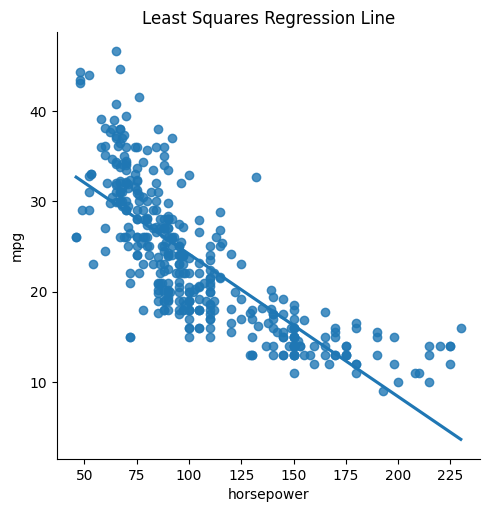

```python
# BEGIN SOLUTION
import seaborn as sns
import matplotlib.pyplot as plt
sns.lmplot(x='horsepower', y='mpg', data=df_processed, ci=None)
plt.title('Least Squares Regression Line')
plt.show()

# END SOLUTION
```

### c) Use the `plot_fit` function from statsmodels library to produce diagnostic plots of the least squares regression fit. Comment on any problems you see with the fit.

Link to plot_fit:

https://www.statsmodels.org/dev/generated/statsmodels.graphics.regressionplots.plot_fit.html

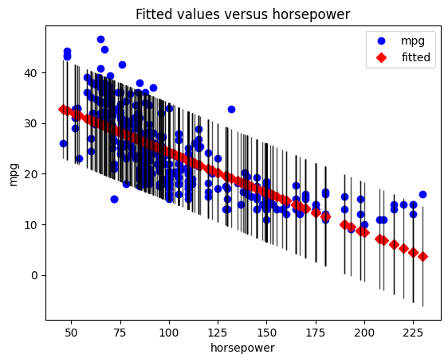

```python
# BEGIN SOLUTION
from statsmodels.graphics.regressionplots import plot_fit
plot_fit(model, 1)
plt.show()


# END SOLUTION
```

The ploat shows that

1. The orginal mpg values are deviating to higher value when horsepower is < 100 and > 180
2. The middle of the regression line is more fit when compared to ones in the beginning and end.
3. There is a lot of variance in data when hoursepower is less than 100. The number of observations are crowded when hoursepower is less than 100
4. It seems the actual relation is of second degree

## Question 5

This question involves the use of multiple linear regression on the Auto data set. Read the dataset first:

### a) Produce a scatterplot matrix using pairplot() from seaborn library which includes all of the variables in the data set

Link to pairplot: https://seaborn.pydata.org/generated/seaborn.pairplot.html

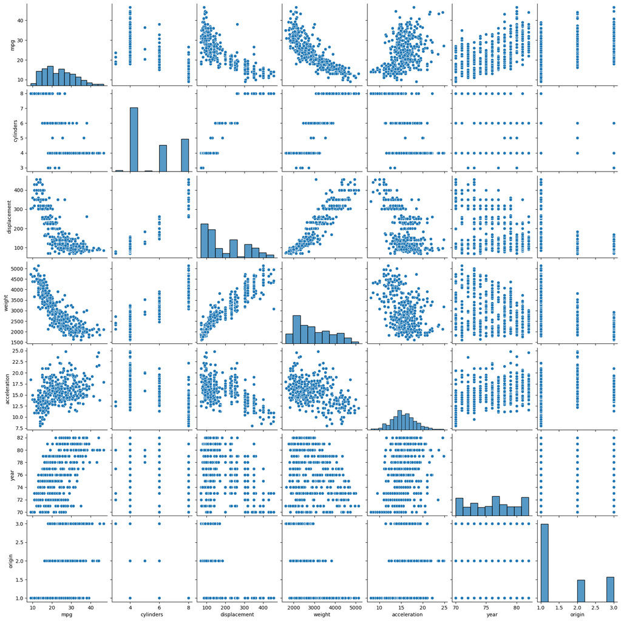

```python
# BEGIN SOLUTION
import seaborn as sns
sns.pairplot(df)
# END SOLUTION
```

### b) Compute the matrix of correlations between the variables using the function `corr()`in pandas on the dataframe also plot the corresponding correlation matrix using `heatmap` function in seaborn

Links:

Corr() : https://pandas.pydata.org/docs/reference/api/pandas.DataFrame.corr.html

Heatmap : https://seaborn.pydata.org/generated/seaborn.heatmap.html

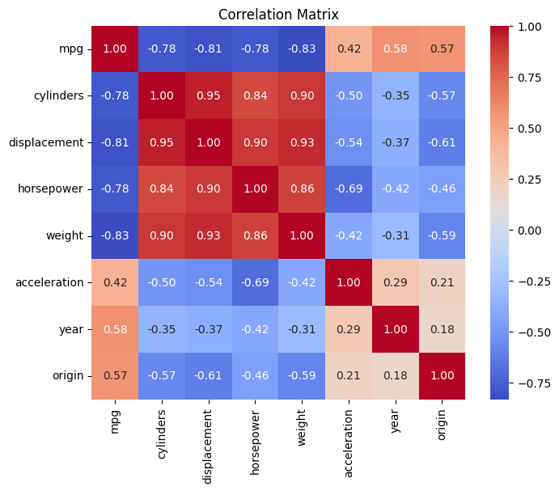

```python
# BEGIN SOLUTION
import matplotlib.pyplot as plt
correlation_matrix = df_processed[["mpg", "cylinders","displacement", "horsepower",	"weight",	"acceleration",	"year",	"origin"]].corr()
plt.figure(figsize=(8, 6))
sns.heatmap(correlation_matrix, annot=True, cmap='coolwarm', fmt='.2f', square=True)
plt.title('Correlation Matrix')
plt.show()

# END SOLUTION
```

### c) Use the `ols()` function from statsmodels library to perform a multiple linear regression with mpg as the response and all other variables except name as the predictors. Use the `summary()` function from statsmodels to print the results. Use the questions below to comment on the output.

Reference to Statsmodels library and ols :

https://www.statsmodels.org/dev/generated/statsmodels.regression.linear_model.OLS.html#generated-statsmodels-regression-linear-model-ols--page-root

Links to summary:

https://www.statsmodels.org/devel/generated/statsmodels.regression.linear_model.OLSResults.summary.html

```python
# BEGIN SOLUTION
X = df_processed[["cylinders", "displacement", "horsepower", "weight", "acceleration", "year", "origin"]]
y = df_processed['mpg']
# Add a constant to the predictor variable X
X = sm.add_constant(X)

X_train, X_test, y_train, y_test = train_test_split(X, y, test_size=0.1, random_state=42)

# Fit the linear regression model
model = sm.OLS(y_train, X_train).fit()

# Print the summary of the model
model.summary()

# END SOLUTION
```

OLS Regression Results

| Dep. Variable: | mpg | R-squared: | 0.817 |
| --- | --- | --- | --- |
| Model: | OLS | Adj. R-squared: | 0.814 |
| Method: | Least Squares | F-statistic: | 220.1 |
| Date: | Mon, 25 Mar 2024 | Prob (F-statistic): | 6.35e-123 |
| Time: | 12:43:04 | Log-Likelihood: | -923.34 |
| No. Observations: | 352 | AIC: | 1863. |
| Df Residuals: | 344 | BIC: | 1894. |
| Df Model: | 7 |  |  |
| Covariance Type: | nonrobust |  |  |

|  | coef | std err | t | P>\|t\| | [0.025 | 0.975] |
| --- | --- | --- | --- | --- | --- | --- |
| const | -17.5586 | 5.046 | -3.479 | 0.001 | -27.484 | -7.633 |
| cylinders | -0.4124 | 0.343 | -1.201 | 0.231 | -1.088 | 0.263 |
| displacement | 0.0162 | 0.008 | 1.999 | 0.046 | 0.000 | 0.032 |
| horsepower | -0.0158 | 0.015 | -1.053 | 0.293 | -0.045 | 0.014 |
| weight | -0.0063 | 0.001 | -9.087 | 0.000 | -0.008 | -0.005 |
| acceleration | 0.0575 | 0.107 | 0.539 | 0.591 | -0.153 | 0.267 |
| year | 0.7546 | 0.055 | 13.647 | 0.000 | 0.646 | 0.863 |
| origin | 1.4615 | 0.299 | 4.891 | 0.000 | 0.874 | 2.049 |

| Omnibus: | 28.414 | Durbin-Watson: | 2.000 |
| --- | --- | --- | --- |
| Prob(Omnibus): | 0.000 | Jarque-Bera (JB): | 46.800 |
| Skew: | 0.520 | Prob(JB): | 6.88e-11 |
| Kurtosis: | 4.453 | Cond. No. | 8.73e+04 |

Notes:  
[1] Standard Errors assume that the covariance matrix of the errors is correctly specified.  
[2] The condition number is large, 8.73e+04. This might indicate that there are  
strong multicollinearity or other numerical problems.

```python
y_train_predicted = model.predict(X_train)
residuals = y_train - y_train_predicted
mse = np.mean(residuals**2)
print("Mean Squared Error (MSE) for training data :", mse)
y_test_predicted = model.predict(X_test)
residuals = y_test - y_test_predicted
mse = np.mean(residuals**2)
print("Mean Squared Error (MSE) for test data :", mse)
```

```
Mean Squared Error (MSE) for training data : 11.115559949956547
Mean Squared Error (MSE) for test data : 8.627183218870334
```

#### i. Is there a significant association between the predictors and the response?

- For cylinders, the p-value is 0.231, which is greater than 0.05. This suggests that there is not a significant association between cylinders and mpg.
- For displacement, the p-value is 0.046, which is less than 0.05. This suggests that there is a significant association between displacement and mpg.
- For horsepower, the p-value is 0.293, which is greater than 0.05. This suggests that there is not a significant association between horsepower and mpg.
- For weight, the p-value is less than 0.001. This suggests that there is a significant association between weight and mpg.
- For acceleration, the p-value is 0.591, which is greater than 0.05. This suggests that there is not a significant association between acceleration and mpg.
- For year, the p-value is less than 0.001. This suggests that there is a significant association between year and mpg.
- For origin, the p-value is less than 0.001. This suggests that there is a significant association between origin and mpg.

#### ii. Which predictors appear to have a statistically significant relationship to the response?

The predictors displacement, weight, year, origin shows statistically significant relationship to the response.

#### iii. What does the coefficient for the year variable suggest?

Coefficient for the year variable is 0.7546. It suggests a positive slope(correlation) which means as time progress, the mpg is improving with time.

### d) Use the `plot_fit ()` function from statsmodels to produce diagnostic plots of the linear regression fit. Again, feel free to use any other package or function to create these plots. Comment on any problems you see with the fit. Do the residual plots suggest any unusually large outliers? Does the leverage plot identify any observations with unusually high leverage?

Link to plot_fit:

https://www.statsmodels.org/dev/generated/statsmodels.graphics.regressionplots.plot_fit.html

Link to residual plots:

https://www.statsmodels.org/dev/generated/statsmodels.graphics.regressionplots.plot_leverage_resid2.html

```python
#using plot_fit()
```

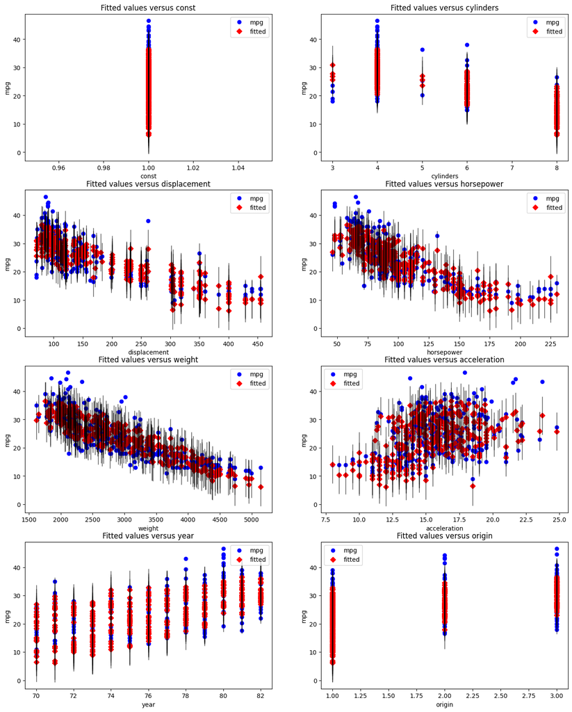

```python
# BEGIN SOLUTION
import matplotlib.pyplot as plt
from statsmodels.graphics.regressionplots import plot_fit

fig, axs = plt.subplots(nrows=4, ncols=2, figsize=(16, 20))
# plot_fit(model, 1, ax=axs[0,0])
for i in range(0,8):
    plot_fit(model, i, ax=axs[int(i/2), int(i % 2)])
plt.show()

# END SOLUTION
```

```python
#using plot_leverage_resid2
```

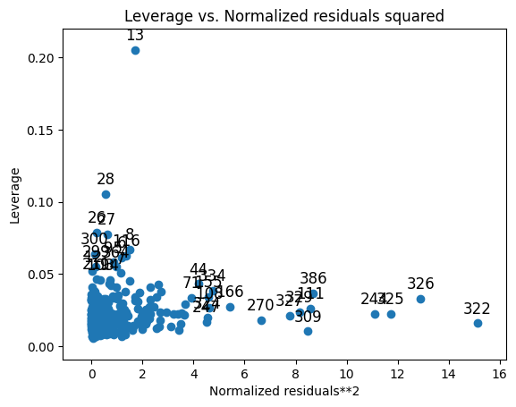

```python
# BEGIN SOLUTION

from statsmodels.graphics.regressionplots import plot_leverage_resid2

# Plot the leverage-residual squared
# fig, axs = plt.subplots(nrows=4, ncols=2, figsize=(16, 20))
# plot_fit(model, 1, ax=axs[0,0])
# for i in range(0,8):
#     plot_leverage_resid2(model, i, ax=axs[int(i/2), int(i % 2)])
# plt.show()
plot_leverage_resid2(model)
plt.show()

# END SOLUTION
```

The point marked by 13 shows a large amount of Leverage of around 0.20. High-leverage points have the potential to cause large changes in the parameter estimates when they are deleted

### e) Fit a linear regression model with interaction effects. explore a few different models (~3–4 models). Do any interactions appear to be statistically significant in any of the models you examined?

Use formula.ols to check the interaction between two predictors as used in the below reference link

https://www.statsmodels.org/devel/example_formulas.html

```python
# BEGIN SOLUTION
from statsmodels.formula.api import ols
train_df = pd.concat([X_train, y_train], axis=1)
model1 = ols('mpg ~ cylinders + displacement + horsepower + weight + acceleration + year + origin + year*horsepower', data=train_df).fit()
model1.summary()
```

OLS Regression Results

| Dep. Variable: | mpg | R-squared: | 0.846 |
| --- | --- | --- | --- |
| Model: | OLS | Adj. R-squared: | 0.843 |
| Method: | Least Squares | F-statistic: | 236.0 |
| Date: | Mon, 25 Mar 2024 | Prob (F-statistic): | 1.79e-134 |
| Time: | 12:43:05 | Log-Likelihood: | -893.13 |
| No. Observations: | 352 | AIC: | 1804. |
| Df Residuals: | 343 | BIC: | 1839. |
| Df Model: | 8 |  |  |
| Covariance Type: | nonrobust |  |  |

|  | coef | std err | t | P>\|t\| | [0.025 | 0.975] |
| --- | --- | --- | --- | --- | --- | --- |
| Intercept | -97.4806 | 10.999 | -8.863 | 0.000 | -119.114 | -75.847 |
| cylinders | 0.1197 | 0.322 | 0.371 | 0.711 | -0.515 | 0.754 |
| displacement | 0.0029 | 0.008 | 0.386 | 0.700 | -0.012 | 0.018 |
| horsepower | 0.8038 | 0.103 | 7.789 | 0.000 | 0.601 | 1.007 |
| weight | -0.0052 | 0.001 | -7.937 | 0.000 | -0.006 | -0.004 |
| acceleration | -0.0480 | 0.099 | -0.485 | 0.628 | -0.243 | 0.147 |
| year | 1.8310 | 0.144 | 12.749 | 0.000 | 1.549 | 2.113 |
| origin | 1.2603 | 0.276 | 4.570 | 0.000 | 0.718 | 1.803 |
| year:horsepower | -0.0113 | 0.001 | -8.014 | 0.000 | -0.014 | -0.009 |

| Omnibus: | 19.870 | Durbin-Watson: | 1.940 |
| --- | --- | --- | --- |
| Prob(Omnibus): | 0.000 | Jarque-Bera (JB): | 29.767 |
| Skew: | 0.408 | Prob(JB): | 3.44e-07 |
| Kurtosis: | 4.168 | Cond. No. | 5.94e+05 |

Notes:  
[1] Standard Errors assume that the covariance matrix of the errors is correctly specified.  
[2] The condition number is large, 5.94e+05. This might indicate that there are  
strong multicollinearity or other numerical problems.

```python
y_train_predicted = model1.predict(X_train)
residuals = y_train - y_train_predicted
mse = np.mean(residuals**2)
print("Mean Squared Error (MSE) for training data :", mse)
y_test_predicted = model1.predict(X_test)
residuals = y_test - y_test_predicted
mse = np.mean(residuals**2)
print("Mean Squared Error (MSE) for test data :", mse)
```

```
Mean Squared Error (MSE) for training data : 9.362518365322414
Mean Squared Error (MSE) for test data : 6.310308172044181
```

```python
model2 = ols('mpg ~ cylinders + displacement + horsepower + weight + acceleration + year + origin + year*cylinders', data=train_df).fit()
model2.summary()
```

OLS Regression Results

| Dep. Variable: | mpg | R-squared: | 0.834 |
| --- | --- | --- | --- |
| Model: | OLS | Adj. R-squared: | 0.830 |
| Method: | Least Squares | F-statistic: | 214.9 |
| Date: | Mon, 25 Mar 2024 | Prob (F-statistic): | 1.28e-128 |
| Time: | 12:43:05 | Log-Likelihood: | -907.01 |
| No. Observations: | 352 | AIC: | 1832. |
| Df Residuals: | 343 | BIC: | 1867. |
| Df Model: | 8 |  |  |
| Covariance Type: | nonrobust |  |  |

|  | coef | std err | t | P>\|t\| | [0.025 | 0.975] |
| --- | --- | --- | --- | --- | --- | --- |
| Intercept | -91.0330 | 13.608 | -6.690 | 0.000 | -117.799 | -64.267 |
| cylinders | 14.3033 | 2.569 | 5.567 | 0.000 | 9.249 | 19.357 |
| displacement | 0.0088 | 0.008 | 1.125 | 0.261 | -0.007 | 0.024 |
| horsepower | -0.0264 | 0.014 | -1.823 | 0.069 | -0.055 | 0.002 |
| weight | -0.0061 | 0.001 | -9.154 | 0.000 | -0.007 | -0.005 |
| acceleration | 0.0964 | 0.102 | 0.942 | 0.347 | -0.105 | 0.298 |
| year | 1.7084 | 0.173 | 9.851 | 0.000 | 1.367 | 2.049 |
| origin | 1.4408 | 0.286 | 5.043 | 0.000 | 0.879 | 2.003 |
| year:cylinders | -0.1891 | 0.033 | -5.774 | 0.000 | -0.253 | -0.125 |

| Omnibus: | 29.274 | Durbin-Watson: | 2.015 |
| --- | --- | --- | --- |
| Prob(Omnibus): | 0.000 | Jarque-Bera (JB): | 45.630 |
| Skew: | 0.554 | Prob(JB): | 1.23e-10 |
| Kurtosis: | 4.373 | Cond. No. | 2.52e+05 |

Notes:  
[1] Standard Errors assume that the covariance matrix of the errors is correctly specified.  
[2] The condition number is large, 2.52e+05. This might indicate that there are  
strong multicollinearity or other numerical problems.

```python
y_train_predicted = model2.predict(X_train)
residuals = y_train - y_train_predicted
mse = np.mean(residuals**2)
print("Mean Squared Error (MSE) for training data :", mse)
y_test_predicted = model2.predict(X_test)
residuals = y_test - y_test_predicted
mse = np.mean(residuals**2)
print("Mean Squared Error (MSE) for test data :", mse)
```

```
Mean Squared Error (MSE) for training data : 10.130704949845953
Mean Squared Error (MSE) for test data : 6.908362559592069
```

```python
model3 = ols('mpg ~ cylinders + displacement + horsepower + weight + acceleration + year + origin + horsepower:origin', data=train_df).fit()
model3.summary()
```

OLS Regression Results

| Dep. Variable: | mpg | R-squared: | 0.840 |
| --- | --- | --- | --- |
| Model: | OLS | Adj. R-squared: | 0.836 |
| Method: | Least Squares | F-statistic: | 224.3 |
| Date: | Mon, 25 Mar 2024 | Prob (F-statistic): | 2.77e-131 |
| Time: | 12:43:05 | Log-Likelihood: | -900.69 |
| No. Observations: | 352 | AIC: | 1819. |
| Df Residuals: | 343 | BIC: | 1854. |
| Df Model: | 8 |  |  |
| Covariance Type: | nonrobust |  |  |

|  | coef | std err | t | P>\|t\| | [0.025 | 0.975] |
| --- | --- | --- | --- | --- | --- | --- |
| Intercept | -21.7927 | 4.779 | -4.560 | 0.000 | -31.192 | -12.393 |
| cylinders | -0.4979 | 0.323 | -1.543 | 0.124 | -1.132 | 0.137 |
| displacement | -0.0032 | 0.008 | -0.393 | 0.695 | -0.019 | 0.013 |
| horsepower | 0.0795 | 0.020 | 4.015 | 0.000 | 0.041 | 0.118 |
| weight | -0.0046 | 0.001 | -6.579 | 0.000 | -0.006 | -0.003 |
| acceleration | -0.1357 | 0.104 | -1.303 | 0.193 | -0.341 | 0.069 |
| year | 0.7340 | 0.052 | 14.114 | 0.000 | 0.632 | 0.836 |
| origin | 7.6866 | 0.950 | 8.095 | 0.000 | 5.819 | 9.554 |
| horsepower:origin | -0.0785 | 0.011 | -6.862 | 0.000 | -0.101 | -0.056 |

| Omnibus: | 46.056 | Durbin-Watson: | 1.993 |
| --- | --- | --- | --- |
| Prob(Omnibus): | 0.000 | Jarque-Bera (JB): | 83.343 |
| Skew: | 0.751 | Prob(JB): | 7.98e-19 |
| Kurtosis: | 4.851 | Cond. No. | 8.82e+04 |

Notes:  
[1] Standard Errors assume that the covariance matrix of the errors is correctly specified.  
[2] The condition number is large, 8.82e+04. This might indicate that there are  
strong multicollinearity or other numerical problems.

```python
y_train_predicted = model3.predict(X_train)
residuals = y_train - y_train_predicted
mse = np.mean(residuals**2)
print("Mean Squared Error (MSE) for training data :", mse)
y_test_predicted = model3.predict(X_test)
residuals = y_test - y_test_predicted
mse = np.mean(residuals**2)
print("Mean Squared Error (MSE) for test data :", mse)
```

```
Mean Squared Error (MSE) for training data : 9.773682429103822
Mean Squared Error (MSE) for test data : 7.105132311022482
```

```python
model4 = ols('mpg ~ cylinders + displacement + horsepower + weight + acceleration + year + origin + horsepower:cylinders', data=train_df).fit()
model4.summary()

# END SOLUTION
```

OLS Regression Results

| Dep. Variable: | mpg | R-squared: | 0.860 |
| --- | --- | --- | --- |
| Model: | OLS | Adj. R-squared: | 0.857 |
| Method: | Least Squares | F-statistic: | 262.9 |
| Date: | Mon, 25 Mar 2024 | Prob (F-statistic): | 2.60e-141 |
| Time: | 12:43:05 | Log-Likelihood: | -876.93 |
| No. Observations: | 352 | AIC: | 1772. |
| Df Residuals: | 343 | BIC: | 1807. |
| Df Model: | 8 |  |  |
| Covariance Type: | nonrobust |  |  |

|  | coef | std err | t | P>\|t\| | [0.025 | 0.975] |
| --- | --- | --- | --- | --- | --- | --- |
| Intercept | 12.5133 | 5.325 | 2.350 | 0.019 | 2.039 | 22.988 |
| cylinders | -4.3258 | 0.489 | -8.852 | 0.000 | -5.287 | -3.365 |
| displacement | -0.0036 | 0.007 | -0.490 | 0.625 | -0.018 | 0.011 |
| horsepower | -0.3207 | 0.033 | -9.795 | 0.000 | -0.385 | -0.256 |
| weight | -0.0038 | 0.001 | -5.762 | 0.000 | -0.005 | -0.002 |
| acceleration | -0.1747 | 0.096 | -1.812 | 0.071 | -0.364 | 0.015 |
| year | 0.7325 | 0.049 | 15.079 | 0.000 | 0.637 | 0.828 |
| origin | 0.9654 | 0.267 | 3.619 | 0.000 | 0.441 | 1.490 |
| horsepower:cylinders | 0.0409 | 0.004 | 10.173 | 0.000 | 0.033 | 0.049 |

| Omnibus: | 36.130 | Durbin-Watson: | 1.875 |
| --- | --- | --- | --- |
| Prob(Omnibus): | 0.000 | Jarque-Bera (JB): | 67.753 |
| Skew: | 0.593 | Prob(JB): | 1.94e-15 |
| Kurtosis: | 4.793 | Cond. No. | 1.08e+05 |

Notes:  
[1] Standard Errors assume that the covariance matrix of the errors is correctly specified.  
[2] The condition number is large, 1.08e+05. This might indicate that there are  
strong multicollinearity or other numerical problems.

```python
y_train_predicted = model4.predict(X_train)
residuals = y_train - y_train_predicted
mse = np.mean(residuals**2)
print("Mean Squared Error (MSE) for training data :", mse)
y_test_predicted = model4.predict(X_test)
residuals = y_test - y_test_predicted
mse = np.mean(residuals**2)
print("Mean Squared Error (MSE) for test data :", mse)
```

```
Mean Squared Error (MSE) for training data : 8.53908170553919
Mean Squared Error (MSE) for test data : 7.10202583195877
```

These are the results of four different OLS (Ordinary Least Squares) regression models. Each model attempts to predict the miles per gallon (`mpg`) of a car based on various features. Here is a brief summary of each model:

1. **Model 1:**
   - R-squared: 0.846
   - Dependent Variable: mpg
   - Independent Variables: cylinders, displacement, horsepower, weight, acceleration, year, origin, year:horsepower
   - Significant predictors: horsepower, weight, year, origin, year:horsepower
   - Year and horsepower interactions appear to be statistically significant.
2. **Model 2:**
   - R-squared: 0.834
   - Dependent Variable: mpg
   - Independent Variables: cylinders, displacement, horsepower, weight, acceleration, year, origin, year:cylinders
   - Significant predictors: cylinders, weight, year, origin, year:cylinders
   - Year and cylinders interactions appear to be statistically significant.
3. **Model 3:**
   - R-squared: 0.840
   - Dependent Variable: mpg
   - Independent Variables: cylinders, displacement, horsepower, weight, acceleration, year, origin, horsepower:origin
   - Significant predictors: horsepower, weight, year, origin, horsepower:origin
   - Horsepower and origin interactions appear to be statistically significant.
4. **Model 4:**
   - R-squared: 0.860
   - Dependent Variable: mpg
   - Independent Variables: cylinders, displacement, horsepower, weight, acceleration, year, origin, horsepower:cylinders
   - Significant predictors: cylinders, horsepower, weight, year, origin, horsepower:cylinders
   - Horsepower and cylinders interactions appear to be statistically significant.

In each model, the R-squared value indicates the proportion of the variance in the dependent variable (mpg) that is predictable from the independent variables. Additionally, significant predictors are those with p-values less than the chosen significance level (usually 0.05), indicating that they have a statistically significant relationship with the dependent variable.

### f) Try a few different transformations of the variables, such as `log(X)`, `sqrt(X)`, $X^2$. Comment on your findings.

```python
# BEGIN SOLUTION
# Add transformed variables to the dataframe
train_df['log_horsepower'] = np.log(train_df['horsepower'])
train_df['sqrt_horsepower'] = np.sqrt(train_df['horsepower'])
train_df['horsepower_squared'] = train_df['horsepower']**2
X_train['log_horsepower'] = np.log(X_train['horsepower'])
X_train['sqrt_horsepower'] = np.sqrt(X_train['horsepower'])
X_train['horsepower_squared'] = X_train['horsepower']**2
X_test['log_horsepower'] = np.log(X_test['horsepower'])
X_test['sqrt_horsepower'] = np.sqrt(X_test['horsepower'])
X_test['horsepower_squared'] = X_test['horsepower']**2

# Fit a model with the transformed variables
model_log_horsepower = ols('mpg ~ cylinders + displacement + horsepower + log_horsepower + acceleration + year + origin', data=train_df).fit()
model_sqrt_horsepower = ols('mpg ~ cylinders + sqrt_horsepower + horsepower + weight + acceleration + year + origin', data=train_df).fit()
model_horsepower_squared = ols('mpg ~ cylinders + horsepower_squared + horsepower + weight + acceleration + year + origin', data=train_df).fit()

print(model_log_horsepower.summary())
print(model_sqrt_horsepower.summary())
print(model_horsepower_squared.summary())

y_train_predicted = model_log_horsepower.predict(X_train)
residuals = y_train - y_train_predicted
mse = np.mean(residuals**2)
print("Mean Squared Error (MSE) for training data (Model with Log horsepower) :", mse)
y_test_predicted = model_log_horsepower.predict(X_test)
residuals = y_test - y_test_predicted
mse = np.mean(residuals**2)
print("Mean Squared Error (MSE) for test data (Model with Log horsepower):", mse)

y_train_predicted = model_sqrt_horsepower.predict(X_train)
residuals = y_train - y_train_predicted
mse = np.mean(residuals**2)
print("Mean Squared Error (MSE) for training data (Model with Sqrt horsepower) :", mse)
y_test_predicted = model_sqrt_horsepower.predict(X_test)
residuals = y_test - y_test_predicted
mse = np.mean(residuals**2)
print("Mean Squared Error (MSE) for test data (Model with Sqrt horsepower):", mse)

y_train_predicted = model_horsepower_squared.predict(X_train)
residuals = y_train - y_train_predicted
mse = np.mean(residuals**2)
print("Mean Squared Error (MSE) for training data (Model with Squared horsepower) :", mse)
y_test_predicted = model_horsepower_squared.predict(X_test)
residuals = y_test - y_test_predicted
mse = np.mean(residuals**2)
print("Mean Squared Error (MSE) for test data (Model with Squared horsepower):", mse)

# END SOLUTION
```

```
                            OLS Regression Results
==============================================================================
Dep. Variable:                    mpg   R-squared:                       0.851
Model:                            OLS   Adj. R-squared:                  0.847
Method:                 Least Squares   F-statistic:                     279.6
Date:                Mon, 25 Mar 2024   Prob (F-statistic):          8.73e-138
Time:                        12:43:05   Log-Likelihood:                -888.22
No. Observations:                 352   AIC:                             1792.
Df Residuals:                     344   BIC:                             1823.
Df Model:                           7
Covariance Type:            nonrobust
==================================================================================
                     coef    std err          t      P>|t|      [0.025      0.975]
----------------------------------------------------------------------------------
Intercept        119.8526     10.707     11.194      0.000      98.794     140.911
cylinders         -0.0041      0.314     -0.013      0.990      -0.622       0.614
displacement      -0.0246      0.007     -3.597      0.000      -0.038      -0.011
horsepower         0.2081      0.025      8.443      0.000       0.160       0.257
log_horsepower   -34.4302      2.590    -13.296      0.000     -39.524     -29.337
acceleration      -0.6166      0.086     -7.189      0.000      -0.785      -0.448
year               0.6951      0.049     14.068      0.000       0.598       0.792
origin             0.9138      0.276      3.311      0.001       0.371       1.457
==============================================================================
Omnibus:                       28.375   Durbin-Watson:                   1.820
Prob(Omnibus):                  0.000   Jarque-Bera (JB):               54.844
Skew:                           0.463   Prob(JB):                     1.23e-12
Kurtosis:                       4.698   Cond. No.                     1.73e+04
==============================================================================

Notes:
[1] Standard Errors assume that the covariance matrix of the errors is correctly specified.
[2] The condition number is large, 1.73e+04. This might indicate that there are
strong multicollinearity or other numerical problems.
                            OLS Regression Results
==============================================================================
Dep. Variable:                    mpg   R-squared:                       0.858
Model:                            OLS   Adj. R-squared:                  0.855
Method:                 Least Squares   F-statistic:                     297.5
Date:                Mon, 25 Mar 2024   Prob (F-statistic):          9.65e-142
Time:                        12:43:05   Log-Likelihood:                -878.87
```

[output cut: 50 more lines]

```
Prob(Omnibus):                  0.000   Jarque-Bera (JB):               35.797
Skew:                           0.398   Prob(JB):                     1.69e-08
Kurtosis:                       4.344   Cond. No.                     4.99e+05
==============================================================================

Notes:
[1] Standard Errors assume that the covariance matrix of the errors is correctly specified.
[2] The condition number is large, 4.99e+05. This might indicate that there are
strong multicollinearity or other numerical problems.
Mean Squared Error (MSE) for training data (Model with Log horsepower) : 9.10493378718262
Mean Squared Error (MSE) for test data (Model with Log horsepower): 9.674322879614584
Mean Squared Error (MSE) for training data (Model with Sqrt horsepower) : 8.634104073056603
Mean Squared Error (MSE) for test data (Model with Sqrt horsepower): 8.231591545831177
Mean Squared Error (MSE) for training data (Model with Squared horsepower) : 8.917682216829029
Mean Squared Error (MSE) for test data (Model with Squared horsepower): 8.069578061668349
```

All three models show the transformations of horsepower to be statistically significant.

**Model Using log(horsepower):**

- R-squared: 0.851
- Adjusted R-squared: 0.847
- Coefficient for log_horsepower: -34.4302
- Coefficient for horsepower: 0.2081

**Model 2:**

- R-squared: 0.858
- Adjusted R-squared: 0.855
- Coefficient for sqrt_horsepower: -10.5768
- Coefficient for horsepower: 0.4234

**Model 3:**

- R-squared: 0.854
- Adjusted R-squared: 0.851
- Coefficient for horsepower_squared: 0.0010
- Coefficient for horsepower: -0.3167

Sqrt and Squared horsepower gives slightly better results when compared to Log hoursepower.

## Question 6

In this exercise you will create some simulated data and will fit simple linear regression models to it. Make sure to use `set.seed(1)` prior to starting part (a) to ensure consistent results.

### a) Using the random normal function, create a vector, `x`, containing 100 observations drawn from a $N(0, 1)$ distribution. This represents a feature, `X`.

Link to random normal function: https://numpy.org/doc/stable/reference/random/generated/numpy.random.normal.html

```python
# BEGIN SOLUTION
np.random.seed(1)
x = np.random.normal(0, 1, 100)
x
# END SOLUTION
```

```
array([ 1.62434536, -0.61175641, -0.52817175, -1.07296862,  0.86540763,
       -2.3015387 ,  1.74481176, -0.7612069 ,  0.3190391 , -0.24937038,
        1.46210794, -2.06014071, -0.3224172 , -0.38405435,  1.13376944,
       -1.09989127, -0.17242821, -0.87785842,  0.04221375,  0.58281521,
       -1.10061918,  1.14472371,  0.90159072,  0.50249434,  0.90085595,
       -0.68372786, -0.12289023, -0.93576943, -0.26788808,  0.53035547,
       -0.69166075, -0.39675353, -0.6871727 , -0.84520564, -0.67124613,
       -0.0126646 , -1.11731035,  0.2344157 ,  1.65980218,  0.74204416,
       -0.19183555, -0.88762896, -0.74715829,  1.6924546 ,  0.05080775,
       -0.63699565,  0.19091548,  2.10025514,  0.12015895,  0.61720311,
        0.30017032, -0.35224985, -1.1425182 , -0.34934272, -0.20889423,
        0.58662319,  0.83898341,  0.93110208,  0.28558733,  0.88514116,
       -0.75439794,  1.25286816,  0.51292982, -0.29809284,  0.48851815,
       -0.07557171,  1.13162939,  1.51981682,  2.18557541, -1.39649634,
       -1.44411381, -0.50446586,  0.16003707,  0.87616892,  0.31563495,
       -2.02220122, -0.30620401,  0.82797464,  0.23009474,  0.76201118,
       -0.22232814, -0.20075807,  0.18656139,  0.41005165,  0.19829972,
        0.11900865, -0.67066229,  0.37756379,  0.12182127,  1.12948391,
        1.19891788,  0.18515642, -0.37528495, -0.63873041,  0.42349435,
        0.07734007, -0.34385368,  0.04359686, -0.62000084,  0.69803203])
```

### b) Using the `random normal` function, create a vector, `eps`, containing 100 observations drawn from a $N(0, 0.25)$ distribution — a normal distribution with mean zero and variance `0.25`.

Link to random normal function: https://numpy.org/doc/stable/reference/random/generated/numpy.random.normal.html

```python
# BEGIN SOLUTION
eps = np.random.normal(0, 0.25, 100)

# END SOLUTION
```

### c) Using `x` and `eps`, generate a vector `y` according to the model $Y = -1 + 0.5X + ϵ$. What is the length of the vector `y`? What are the values of $β_0$ and $β_1$ in this linear model?

```python
# BEGIN SOLUTION
y = -1 + 0.5*x + eps
print(f"The size of y is {len(y)}")
# END SOLUTION
```

```
The size of y is 100
```

- $β_0 = -1$
- $β_1 = 0.5$
- $dim(y) = 100$

### d) Create a scatterplot displaying the relationship between `x` and `y`. Comment on what you observe.

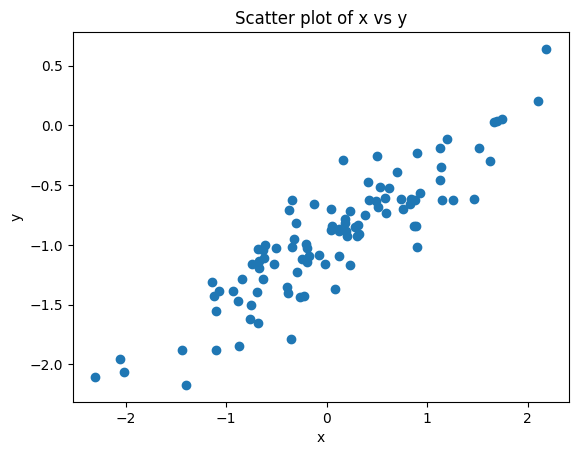

```python
# BEGIN SOLUTION
import matplotlib.pyplot as plt

plt.scatter(x, y)
plt.xlabel('x')
plt.ylabel('y')
plt.title('Scatter plot of x vs y')
plt.show()


# END SOLUTION
```

The plot shows that there is a positive correlation and there is linear relationship. But the linear relationship is not very clear as center part has lot of points because points are concentrated over the mean.

### e) Fit a least squares linear model that relates y and `x`. Comment on the model obtained. How do the estimated coefficients (slope and intercept) compare to the true values used to simulate the data?

```python
# BEGIN SOLUTION

X = sm.add_constant(x)
model = sm.OLS(y, X).fit()
intercept = model.params[0]
slope = model.params[1]
model.summary()

# END SOLUTION
```

OLS Regression Results

| Dep. Variable: | y | R-squared: | 0.800 |
| --- | --- | --- | --- |
| Model: | OLS | Adj. R-squared: | 0.798 |
| Method: | Least Squares | F-statistic: | 391.4 |
| Date: | Mon, 25 Mar 2024 | Prob (F-statistic): | 5.39e-36 |
| Time: | 12:43:05 | Log-Likelihood: | 4.1908 |
| No. Observations: | 100 | AIC: | -4.382 |
| Df Residuals: | 98 | BIC: | 0.8288 |
| Df Model: | 1 |  |  |
| Covariance Type: | nonrobust |  |  |

|  | coef | std err | t | P>\|t\| | [0.025 | 0.975] |
| --- | --- | --- | --- | --- | --- | --- |
| const | -0.9632 | 0.023 | -40.999 | 0.000 | -1.010 | -0.917 |
| x1 | 0.5239 | 0.026 | 19.783 | 0.000 | 0.471 | 0.576 |

| Omnibus: | 0.898 | Durbin-Watson: | 2.157 |
| --- | --- | --- | --- |
| Prob(Omnibus): | 0.638 | Jarque-Bera (JB): | 0.561 |
| Skew: | -0.172 | Prob(JB): | 0.755 |
| Kurtosis: | 3.127 | Cond. No. | 1.15 |

Notes:  
[1] Standard Errors assume that the covariance matrix of the errors is correctly specified.

- Slope is predicted to be 0.5239 which shows a difference of 0.02 from the real value.
- Intercept is predicted to be -0.96324662 which shows a difference of 0.04 from real value.
- Also note that the R-squared value is 0.8. That means model explains 80% of the data.

### f) Display the least squares line on the scatterplot obtained in (d). Draw the estimated regression line on the plot, in a different color. Feel free to use any framework such as ggplot or matplotlib, seaborn etc

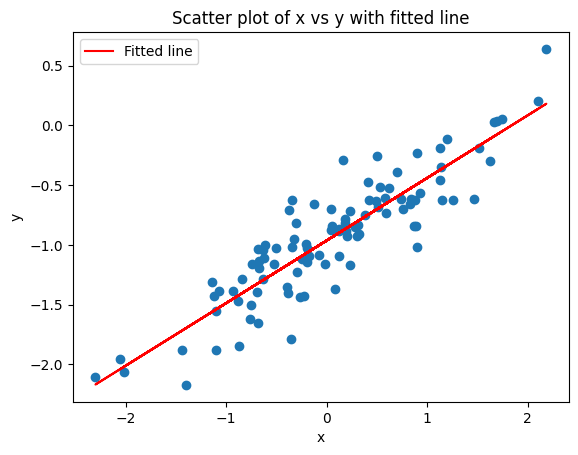

```python
# BEGIN SOLUTION

plt.scatter(x, y)
plt.plot(x, intercept + slope*x, 'r', label='Fitted line')
plt.xlabel('x')
plt.ylabel('y')
plt.title('Scatter plot of x vs y with fitted line')
plt.legend()
plt.show()
```

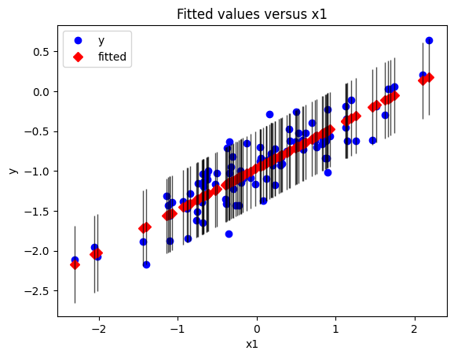

```python
plot_fit(model, 1)
plt.show()
# END SOLUTION
```

The line we have predicted fits well with the data.

### g) Now fit a polynomial regression model that predicts $y$ using $x$ and $x^2$. Is there evidence that the quadratic term improves the model fit? Explain your answer.

```python
# BEGIN SOLUTION
X = np.column_stack((x, x**2))
X = sm.add_constant(X)  # adding a constant for the intercept term
model_polynomial = sm.OLS(y, X).fit()
model_polynomial.summary()


# END SOLUTION
```

OLS Regression Results

| Dep. Variable: | y | R-squared: | 0.800 |
| --- | --- | --- | --- |
| Model: | OLS | Adj. R-squared: | 0.796 |
| Method: | Least Squares | F-statistic: | 193.8 |
| Date: | Mon, 25 Mar 2024 | Prob (F-statistic): | 1.32e-34 |
| Time: | 12:43:05 | Log-Likelihood: | 4.2077 |
| No. Observations: | 100 | AIC: | -2.415 |
| Df Residuals: | 97 | BIC: | 5.400 |
| Df Model: | 2 |  |  |
| Covariance Type: | nonrobust |  |  |

|  | coef | std err | t | P>\|t\| | [0.025 | 0.975] |
| --- | --- | --- | --- | --- | --- | --- |
| const | -0.9663 | 0.029 | -33.486 | 0.000 | -1.024 | -0.909 |
| x1 | 0.5234 | 0.027 | 19.582 | 0.000 | 0.470 | 0.576 |
| x2 | 0.0039 | 0.021 | 0.181 | 0.856 | -0.038 | 0.046 |

| Omnibus: | 0.893 | Durbin-Watson: | 2.152 |
| --- | --- | --- | --- |
| Prob(Omnibus): | 0.640 | Jarque-Bera (JB): | 0.552 |
| Skew: | -0.170 | Prob(JB): | 0.759 |
| Kurtosis: | 3.132 | Cond. No. | 2.10 |

Notes:  
[1] Standard Errors assume that the covariance matrix of the errors is correctly specified.

### h) Repeat (a)–(f) after modifying the data generation process in such a way that there is less noise in the data. The model analyzed in this section,, should remain the same. You can do this by decreasing the variance of the normal distribution used to generate the error term ϵ in (b). Describe your results.

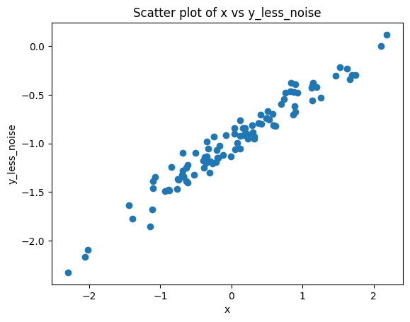

```python
# BEGIN SOLUTION
eps_less_noise = np.random.normal(0, 0.1, 100)
y_less_noise = -1 + 0.5*x + eps_less_noise

import matplotlib.pyplot as plt

plt.scatter(x, y_less_noise)
plt.xlabel('x')
plt.ylabel('y_less_noise')
plt.title('Scatter plot of x vs y_less_noise')
plt.show()

# END SOLUTION
```

```python
X = sm.add_constant(x)
model_less_noise = sm.OLS(y_less_noise, X).fit()
intercept = model_less_noise.params[0]
slope = model_less_noise.params[1]
model_less_noise.summary()
```

OLS Regression Results

| Dep. Variable: | y | R-squared: | 0.950 |
| --- | --- | --- | --- |
| Model: | OLS | Adj. R-squared: | 0.950 |
| Method: | Least Squares | F-statistic: | 1872. |
| Date: | Mon, 25 Mar 2024 | Prob (F-statistic): | 1.14e-65 |
| Time: | 12:43:05 | Log-Likelihood: | 87.938 |
| No. Observations: | 100 | AIC: | -171.9 |
| Df Residuals: | 98 | BIC: | -166.7 |
| Df Model: | 1 |  |  |
| Covariance Type: | nonrobust |  |  |

|  | coef | std err | t | P>\|t\| | [0.025 | 0.975] |
| --- | --- | --- | --- | --- | --- | --- |
| const | -0.9988 | 0.010 | -98.222 | 0.000 | -1.019 | -0.979 |
| x1 | 0.4959 | 0.011 | 43.268 | 0.000 | 0.473 | 0.519 |

| Omnibus: | 0.264 | Durbin-Watson: | 2.186 |
| --- | --- | --- | --- |
| Prob(Omnibus): | 0.876 | Jarque-Bera (JB): | 0.398 |
| Skew: | 0.107 | Prob(JB): | 0.820 |
| Kurtosis: | 2.776 | Cond. No. | 1.15 |

Notes:  
[1] Standard Errors assume that the covariance matrix of the errors is correctly specified.

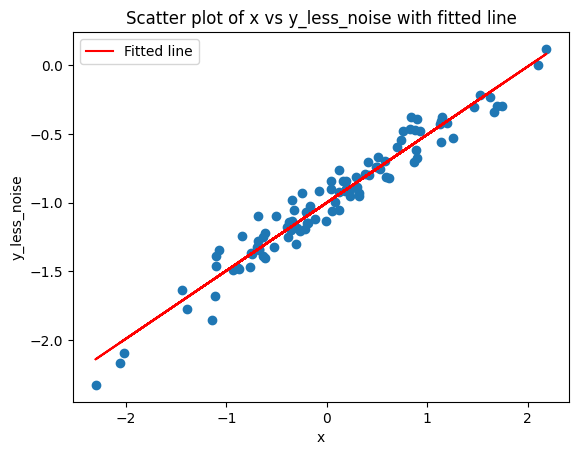

```python
plt.scatter(x, y_less_noise)
plt.plot(x, intercept + slope*x, 'r', label='Fitted line')
plt.xlabel('x')
plt.ylabel('y_less_noise')
plt.title('Scatter plot of x vs y_less_noise with fitted line')
plt.legend()
plt.show()
```

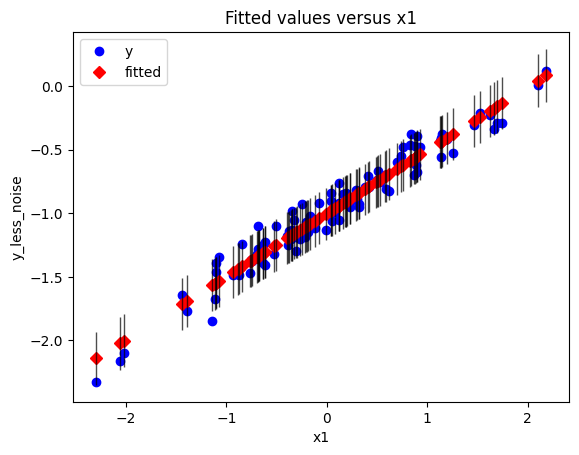

```python
plot_fit(model_less_noise, 1)
plt.ylabel('y_less_noise')
plt.show()
```

### i) Repeat (a)–(f) after modifying the data generation process in such a way that there is more noise in the data. The model analyzed in this section ($Y = -1 + 0.5X + ϵ$) should remain the same. You can do this by increasing the variance of the normal distribution used to generate the error term $ϵ$ in (b). Describe your results.

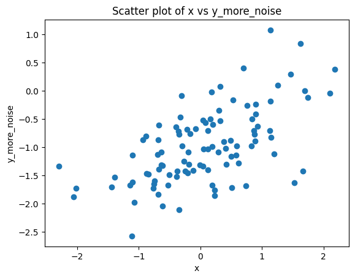

```python
# BEGIN SOLUTION
eps_more_noise = np.random.normal(0, 0.5, 100)
y_more_noise = -1 + 0.5*x + eps_more_noise
import matplotlib.pyplot as plt

plt.scatter(x, y_more_noise)
plt.xlabel('x')
plt.ylabel('y_more_noise')
plt.title('Scatter plot of x vs y_more_noise')
plt.show()

# END SOLUTION
```

```python
X = sm.add_constant(x)
model_more_noise = sm.OLS(y_more_noise, X).fit()
intercept = model_more_noise.params[0]
slope = model_more_noise.params[1]
model_more_noise.summary()
```

OLS Regression Results

| Dep. Variable: | y | R-squared: | 0.358 |
| --- | --- | --- | --- |
| Model: | OLS | Adj. R-squared: | 0.351 |
| Method: | Least Squares | F-statistic: | 54.63 |
| Date: | Mon, 25 Mar 2024 | Prob (F-statistic): | 4.93e-11 |
| Time: | 12:43:06 | Log-Likelihood: | -78.434 |
| No. Observations: | 100 | AIC: | 160.9 |
| Df Residuals: | 98 | BIC: | 166.1 |
| Df Model: | 1 |  |  |
| Covariance Type: | nonrobust |  |  |

|  | coef | std err | t | P>\|t\| | [0.025 | 0.975] |
| --- | --- | --- | --- | --- | --- | --- |
| const | -1.0070 | 0.054 | -18.760 | 0.000 | -1.114 | -0.900 |
| x1 | 0.4472 | 0.061 | 7.391 | 0.000 | 0.327 | 0.567 |

| Omnibus: | 0.673 | Durbin-Watson: | 2.042 |
| --- | --- | --- | --- |
| Prob(Omnibus): | 0.714 | Jarque-Bera (JB): | 0.286 |
| Skew: | 0.080 | Prob(JB): | 0.867 |
| Kurtosis: | 3.207 | Cond. No. | 1.15 |

Notes:  
[1] Standard Errors assume that the covariance matrix of the errors is correctly specified.

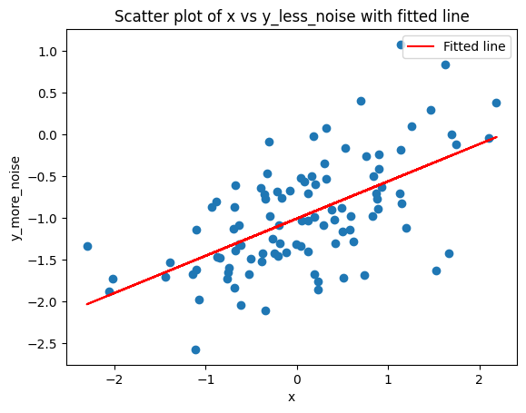

```python
plt.scatter(x, y_more_noise)
plt.plot(x, intercept + slope*x, 'r', label='Fitted line')
plt.xlabel('x')
plt.ylabel('y_more_noise')
plt.title('Scatter plot of x vs y_less_noise with fitted line')
plt.legend()
plt.show()
```

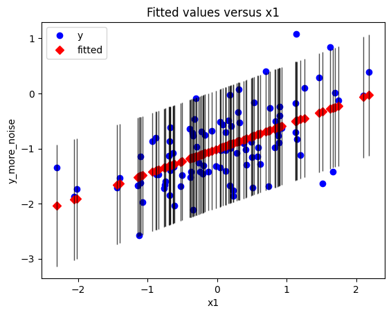

```python
plot_fit(model_more_noise, 1)
plt.ylabel('y_more_noise')
plt.show()
```

### j) What are the confidence intervals for $β_0$ and $β_1$ based on the original data set, the noisier data set, and the less noisy data set? Comment on your results.

```python
# BEGIN SOLUTION
print("For Orginal Data")
c = model.conf_int(alpha=0.05)
print("Confidence intervals for beta_0:", c[0])
print("Confidence intervals for beta_1:", c[1])
print("For Less Noisy Data")
c = model_less_noise.conf_int(alpha=0.05)
print("Confidence intervals for beta_0:", c[0])
print("Confidence intervals for beta_1:", c[1])
print("For More Noisy Data")
c = model_more_noise.conf_int(alpha=0.05)
print("Confidence intervals for beta_0:", c[0])
print("Confidence intervals for beta_1:", c[1])

# END SOLUTION
```

```
For Orginal Data
Confidence intervals for beta_0: [-1.00987048 -0.91662275]
Confidence intervals for beta_1: [0.47130669 0.57640688]
For Less Noisy Data
Confidence intervals for beta_0: [-1.01894809 -0.97859004]
Confidence intervals for beta_1: [0.4731502  0.51863806]
For More Noisy Data
Confidence intervals for beta_0: [-1.11350365 -0.90045807]
Confidence intervals for beta_1: [0.32711096 0.56723617]
```

For confidenence levels of the $\beta_1$ and $\beta_0$ is narrower when the error in the data is less. As the noise increases the confidence seems to spread out.

## Question 7

This question focuses on the collinearity problem

## (a) Perform the following commands in `Python`

```python
import numpy as np

np.random.seed(1)

x1 = np.random.uniform(size=100)

x2 = 0.5 * x1 + np.random.normal(size=100) / 10

y = 2 + 2 * x1 + 0.3 * x2 + np.random.normal(size=100)
```

The last line corresponds to creating a linear model in which $y$ is a function of $x_1$ and $x_2$. Write out the form of the linear model. What are the regression coefficients?

In other words we can write it as $ y = 2 + 2 x_1 + 0.3 x_2 + \varepsilon $

## (b) What is the correlation between $x_1$ and $x_2$? Create a scatterplot displaying the relationship between the variables.

link to correlation function: https://numpy.org/doc/stable/reference/generated/numpy.corrcoef.html

```
Correlation between x1 and x2: 0.8390596222844916
```

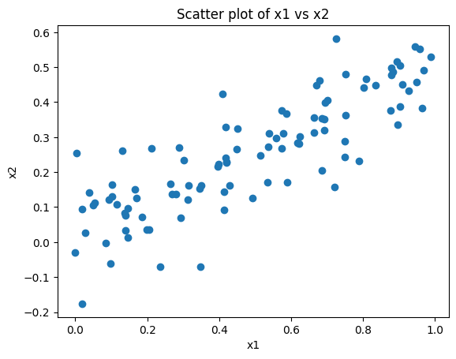

```python
# BEGIN SOLUTION
corr = np.corrcoef(x1, x2)[0, 1]
print("Correlation between x1 and x2:", corr)

import matplotlib.pyplot as plt

plt.scatter(x1, x2)
plt.xlabel('x1')
plt.ylabel('x2')
plt.title('Scatter plot of x1 vs x2')
plt.show()

# END SOLUTION
```

## (c) Using this data, fit a least squares regression to predict $y$ using $x_1$ and $x_2$. Describe the results obtained. What are $β_0$, $β_1$, and $β_2$? How do these relate to the true $β_0$, $β_1$, and $β_2$? Can you reject the null hypothesis $H_0$: $β_1$ = 0? How about the null hypothesis $H_0$: $β_2$ = 0?

```python
# BEGIN SOLUTION
import statsmodels.api as sm

X = np.column_stack((x1, x2))
X = sm.add_constant(X)
model = sm.OLS(y, X).fit()
print(model.summary())
# END SOLUTION
```

```
                            OLS Regression Results
==============================================================================
Dep. Variable:                      y   R-squared:                       0.261
Model:                            OLS   Adj. R-squared:                  0.245
Method:                 Least Squares   F-statistic:                     17.09
Date:                Mon, 25 Mar 2024   Prob (F-statistic):           4.40e-07
Time:                        12:43:06   Log-Likelihood:                -142.34
No. Observations:                 100   AIC:                             290.7
Df Residuals:                      97   BIC:                             298.5
Df Model:                           2
Covariance Type:            nonrobust
==============================================================================
                 coef    std err          t      P>|t|      [0.025      0.975]
------------------------------------------------------------------------------
const          2.1893      0.199     11.021      0.000       1.795       2.584
x1             0.7046      0.637      1.107      0.271      -0.559       1.968
x2             2.5024      1.140      2.194      0.031       0.239       4.766
==============================================================================
Omnibus:                        0.607   Durbin-Watson:                   2.111
Prob(Omnibus):                  0.738   Jarque-Bera (JB):                0.577
Skew:                          -0.179   Prob(JB):                        0.749
Kurtosis:                       2.900   Cond. No.                         14.3
==============================================================================

Notes:
[1] Standard Errors assume that the covariance matrix of the errors is correctly specified.
```

Provide you comments / answer here

R-squared value for the model is 0.261 which means model doesn't explain the most of the data. it only explains 26.1 % of the data.

Only constant value is very close as true value of the contant in orginal model. The values for $\beta_1$ and $\beta_2$ are given by 0.7046 and 2.5024 which is not at all close to true value of coefficients. This is expected as $x_1$ and $x_2$ are highly correlated with correlation of 0.84

- Assuming $\alpha$ is 0.05, i.e, 5% significance level, we can reject null hypothesis for $ \beta_0 $ given by $H_0: \beta_0 = 0$ as p-value is practically 0.
- For $ \beta_1 $, The null hypothesis given by $H_0: \beta_1 = 0$ cannot be rejected as p-value is practically 0.271 which is much greater than 0.05.
- For $ \beta_2 $, The null hypothesis given by $H_0: \beta_2 = 0$ can be rejected as p-value is practically 0.031 which is less than 0.05.

## (d) Now fit a least squares regression to predict $y$ using only $x_1$. Comment on your results. Can you reject the null hypothesis $H_0$: $β_1$ = 0?

```python
# BEGIN SOLUTION
X = sm.add_constant(x1)
model_x1 = sm.OLS(y, X).fit()
print(model_x1.summary())
# END SOLUTION
```

```
                            OLS Regression Results
==============================================================================
Dep. Variable:                      y   R-squared:                       0.224
Model:                            OLS   Adj. R-squared:                  0.216
Method:                 Least Squares   F-statistic:                     28.26
Date:                Mon, 25 Mar 2024   Prob (F-statistic):           6.68e-07
Time:                        12:43:06   Log-Likelihood:                -144.76
No. Observations:                 100   AIC:                             293.5
Df Residuals:                      98   BIC:                             298.7
Df Model:                           1
Covariance Type:            nonrobust
==============================================================================
                 coef    std err          t      P>|t|      [0.025      0.975]
------------------------------------------------------------------------------
const          2.2486      0.201     11.209      0.000       1.850       2.647
x1             1.8770      0.353      5.316      0.000       1.176       2.578
==============================================================================
Omnibus:                        0.292   Durbin-Watson:                   2.123
Prob(Omnibus):                  0.864   Jarque-Bera (JB):                0.468
Skew:                          -0.003   Prob(JB):                        0.791
Kurtosis:                       2.665   Cond. No.                         4.26
==============================================================================

Notes:
[1] Standard Errors assume that the covariance matrix of the errors is correctly specified.
```

The coefficient of const is 2.2486 ($\widehat{\beta_0}$) and coefficient of $ x_1 $ is 1.8770 ($\widehat{\beta_1}$). The predicted values seems to be closer to the orginal value. The increase in coefficient of const might be to balance the effect of $x_2$ in the model.

In the provided OLS regression results, the p-value for the coefficient $ \beta_1 $ is 0.000, which is less than the typical significance level of 0.05. Therefore, we can reject the null hypothesis $ H_0: \beta_1 = 0 $ and conclude that there is sufficient evidence to suggest that $ x_1 $ has a statistically significant effect on $ y $.

## (e) Now fit a least squares regression to predict $y$ using only $x_2$. Comment on your results. Can you reject the null hypothesis $H_0$: $β_1$ = 0?

```python
# BEGIN SOLUTION
X = sm.add_constant(x2)
model_x1 = sm.OLS(y, X).fit()
print(model_x1.summary())
# END SOLUTION
```

```
                            OLS Regression Results
==============================================================================
Dep. Variable:                      y   R-squared:                       0.251
Model:                            OLS   Adj. R-squared:                  0.244
Method:                 Least Squares   F-statistic:                     32.87
Date:                Mon, 25 Mar 2024   Prob (F-statistic):           1.09e-07
Time:                        12:43:06   Log-Likelihood:                -142.97
No. Observations:                 100   AIC:                             289.9
Df Residuals:                      98   BIC:                             295.1
Df Model:                           1
Covariance Type:            nonrobust
==============================================================================
                 coef    std err          t      P>|t|      [0.025      0.975]
------------------------------------------------------------------------------
const          2.2655      0.187     12.145      0.000       1.895       2.636
x1             3.5613      0.621      5.733      0.000       2.329       4.794
==============================================================================
Omnibus:                        0.857   Durbin-Watson:                   2.117
Prob(Omnibus):                  0.651   Jarque-Bera (JB):                0.746
Skew:                          -0.210   Prob(JB):                        0.689
Kurtosis:                       2.946   Cond. No.                         6.48
==============================================================================

Notes:
[1] Standard Errors assume that the covariance matrix of the errors is correctly specified.
```

The coefficient of const is 2.2655 ($\widehat{\beta_0}$) and coefficient of $ x_1 $ is 3.5613 ($\widehat{\beta_1}$). The predicted values seems to be closer to the orginal value fro constant. The increase in coefficient of constant and $x_2$ might be to balance the effect of missing $x_1$ in the model. The model seems to explain 25.1 % of data as R-squared value is 0.251

## (f) Do the results obtained in (c)–(e) contradict each other? Explain your answer.

The actual equation is $ y = 2 + 2 x_1 + 0.3 x_2 + \varepsilon_1 $ and $x_2 = 0.5 * x_1 + \varepsilon_2 $,

For model with only x1, actual equation becomes $ y = 2 + 2 x_1 + 0.3 (0.5 x_1 + \varepsilon_2) + \varepsilon_1 $ i.e, $ y = 2 + 2 x_1 + 0.15 * x_1 + 0.3 \varepsilon_2 + \varepsilon_1 = 2 + 2.15 x_1 + \varepsilon$, Also note that error also increases, when we did this change. Considering the higher error, the predicted model seems to be close enough to be considered as correct.

Similarly for $x_2$, $ y = 2 + 2.15 (\frac{x_2 - \varepsilon_1}{0.5}) + \varepsilon = 2 + 4.3 x_2 + \varepsilon$, Which is again correct as the predicted value is close to real value.

Also note that, for models with only $x_1$ ([1.176, 2.578]) and only $x_2$ ([2.329, 4.794]) , we can see that the actual true coefficients are within the confidence intervel.

## (g) Now suppose we obtain one additional observation, which was unfortunately mismeasured. Re-fit the linear models from (c) to (e) using this new data. What effect does this new observation have on each of the models? In each model, is this observation an outlier? A high-leverage point? Both? Explain your answers.

```python
# BEGIN SOLUTION
mismeasured_observation_y = 6
mismeasured_observation_x1 = 0.01
mismeasured_observation_x2 = 0.5 * mismeasured_observation_x1 + np.random.normal() / 10
y_new = np.append(y, mismeasured_observation_y)
x1_new = np.append(x1, mismeasured_observation_x1)
x2_new = np.append(x2, mismeasured_observation_x2)
X = np.column_stack((x1_new, x2_new))
X = sm.add_constant(X)
model = sm.OLS(y_new, X).fit()
print(model.summary())
# END SOLUTION
```

```
                            OLS Regression Results
==============================================================================
Dep. Variable:                      y   R-squared:                       0.195
Model:                            OLS   Adj. R-squared:                  0.179
Method:                 Least Squares   F-statistic:                     11.90
Date:                Mon, 25 Mar 2024   Prob (F-statistic):           2.35e-05
Time:                        12:43:06   Log-Likelihood:                -150.39
No. Observations:                 101   AIC:                             306.8
Df Residuals:                      98   BIC:                             314.6
Df Model:                           2
Covariance Type:            nonrobust
==============================================================================
                 coef    std err          t      P>|t|      [0.025      0.975]
------------------------------------------------------------------------------
const          2.3417      0.208     11.269      0.000       1.929       2.754
x1             0.7435      0.680      1.094      0.277      -0.605       2.092
x2             1.9725      1.209      1.632      0.106      -0.426       4.371
==============================================================================
Omnibus:                        4.126   Durbin-Watson:                   1.931
Prob(Omnibus):                  0.127   Jarque-Bera (JB):                3.889
Skew:                           0.274   Prob(JB):                        0.143
Kurtosis:                       3.790   Cond. No.                         14.3
==============================================================================

Notes:
[1] Standard Errors assume that the covariance matrix of the errors is correctly specified.
```

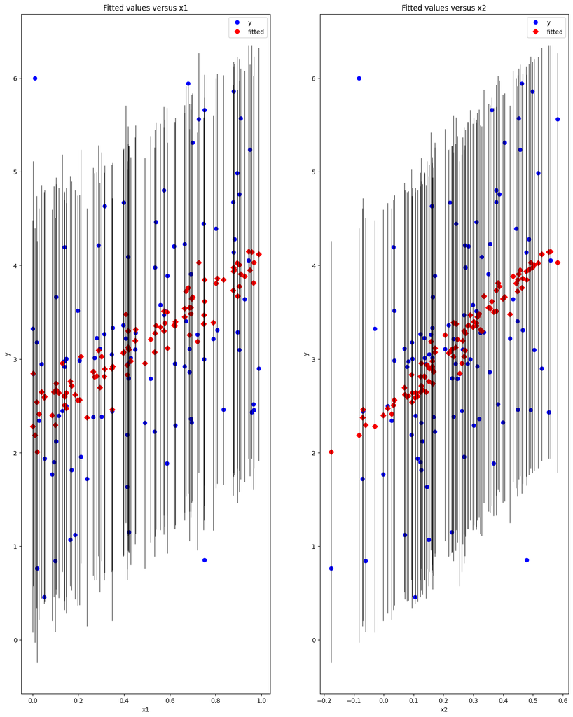

```python
fig, axs = plt.subplots(ncols=2, figsize=(16, 20))
# plot_fit(model, 1, ax=axs[0,0])
for i in range(1,3):
    plot_fit(model, i, ax=axs[i-1])
plt.show()
```

```
Leverage for 101th point is  0.04903583735649794
```

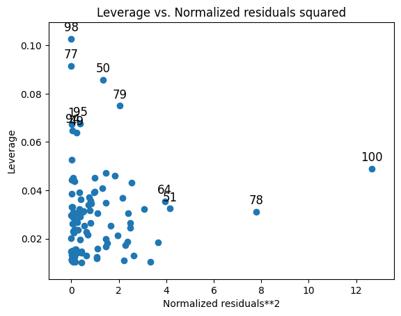

```python
influence = model.get_influence()
leverage = influence.hat_matrix_diag
print("Leverage for 101th point is ", leverage[100])
plot_leverage_resid2(model)
plt.show()
```

```python
X = sm.add_constant(x1_new)
model = sm.OLS(y_new, X).fit()
print(model.summary())
```

```
                            OLS Regression Results
==============================================================================
Dep. Variable:                      y   R-squared:                       0.174
Model:                            OLS   Adj. R-squared:                  0.165
Method:                 Least Squares   F-statistic:                     20.80
Date:                Mon, 25 Mar 2024   Prob (F-statistic):           1.46e-05
Time:                        12:43:06   Log-Likelihood:                -151.74
No. Observations:                 101   AIC:                             307.5
Df Residuals:                      99   BIC:                             312.7
Df Model:                           1
Covariance Type:            nonrobust
==============================================================================
                 coef    std err          t      P>|t|      [0.025      0.975]
------------------------------------------------------------------------------
const          2.3807      0.208     11.437      0.000       1.968       2.794
x1             1.6792      0.368      4.560      0.000       0.949       2.410
==============================================================================
Omnibus:                        2.667   Durbin-Watson:                   1.968
Prob(Omnibus):                  0.263   Jarque-Bera (JB):                2.042
Skew:                           0.301   Prob(JB):                        0.360
Kurtosis:                       3.351   Cond. No.                         4.21
==============================================================================

Notes:
[1] Standard Errors assume that the covariance matrix of the errors is correctly specified.
```

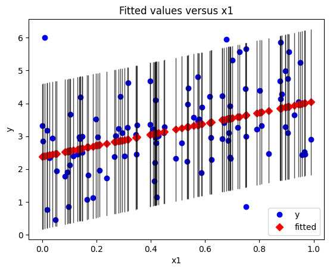

```python
plot_fit(model, 1)
plt.show()
```

```
Leverage for 101th point is  0.03486854481541406
```

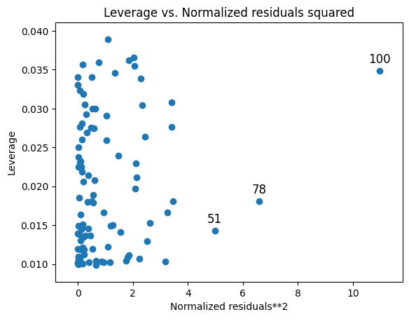

```python
influence = model.get_influence()
leverage = influence.hat_matrix_diag
print("Leverage for 101th point is ", leverage[100])
plot_leverage_resid2(model)
plt.show()
```

```python
X = sm.add_constant(x2_new)
model = sm.OLS(y_new, X).fit()
print(model.summary())
```

```
                            OLS Regression Results
==============================================================================
Dep. Variable:                      y   R-squared:                       0.186
Model:                            OLS   Adj. R-squared:                  0.177
Method:                 Least Squares   F-statistic:                     22.57
Date:                Mon, 25 Mar 2024   Prob (F-statistic):           6.87e-06
Time:                        12:43:06   Log-Likelihood:                -151.00
No. Observations:                 101   AIC:                             306.0
Df Residuals:                      99   BIC:                             311.2
Df Model:                           1
Covariance Type:            nonrobust
==============================================================================
                 coef    std err          t      P>|t|      [0.025      0.975]
------------------------------------------------------------------------------
const          2.4229      0.194     12.471      0.000       2.037       2.808
x1             3.0875      0.650      4.751      0.000       1.798       4.377
==============================================================================
Omnibus:                        4.014   Durbin-Watson:                   1.933
Prob(Omnibus):                  0.134   Jarque-Bera (JB):                3.892
Skew:                           0.244   Prob(JB):                        0.143
Kurtosis:                       3.828   Cond. No.                         6.37
==============================================================================

Notes:
[1] Standard Errors assume that the covariance matrix of the errors is correctly specified.
```

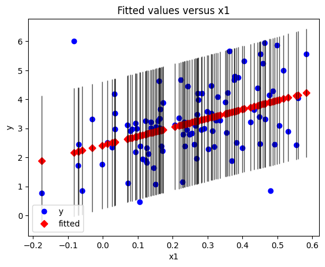

```python
plot_fit(model, 1)
plt.show()
```

```
Leverage for 101th point is  0.04879531296952055
```

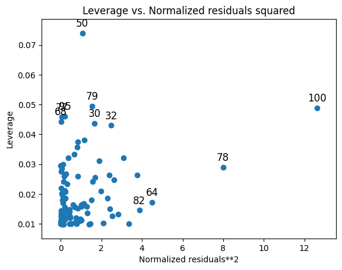

```python
influence = model.get_influence()
leverage = influence.hat_matrix_diag
print("Leverage for 101th point is ", leverage[100])
plot_leverage_resid2(model)
plt.show()
```

One mismeasured observation has caused the error in the models to be increased resulting in lesser R-squared value with their orginal counterpart. For every models, this point seems to an outlier, but having only medium level of leverage.

- For model with x1 and x2), the Leverage is 0.04903583735649794
- For model with x1 only, the Leverage is 0.03486854481541406
- For model with x2 only, the Leverage is 0.04879531296952055

## Question 8

It is claimed that in the case of simple linear regression of $Y$ onto $X$, the $R^2$ statistic is equal to the square of the correlation between $X$ and $Y$. Generate some synthetic data and show that this is the case.

link to correlation function: https://numpy.org/doc/stable/reference/generated/numpy.corrcoef.html

```
                            OLS Regression Results
==============================================================================
Dep. Variable:                      y   R-squared:                       0.970
Model:                            OLS   Adj. R-squared:                  0.969
Method:                 Least Squares   F-statistic:                     3142.
Date:                Mon, 25 Mar 2024   Prob (F-statistic):           2.91e-76
Time:                        12:43:07   Log-Likelihood:                 82.990
No. Observations:                 100   AIC:                            -162.0
Df Residuals:                      98   BIC:                            -156.8
Df Model:                           1
Covariance Type:            nonrobust
==============================================================================
                 coef    std err          t      P>|t|      [0.025      0.975]
------------------------------------------------------------------------------
const          0.0230      0.020      1.129      0.262      -0.017       0.064
x1             1.9618      0.035     56.055      0.000       1.892       2.031
==============================================================================
Omnibus:                        1.097   Durbin-Watson:                   2.065
Prob(Omnibus):                  0.578   Jarque-Bera (JB):                0.898
Skew:                          -0.232   Prob(JB):                        0.638
Kurtosis:                       2.998   Cond. No.                         4.16
==============================================================================

Notes:
[1] Standard Errors assume that the covariance matrix of the errors is correctly specified.
Correlation coefficient: 0.9847610553982763
Square of Correlation coefficient: 0.969754336229127
R-squared: 0.9697543362291268
```

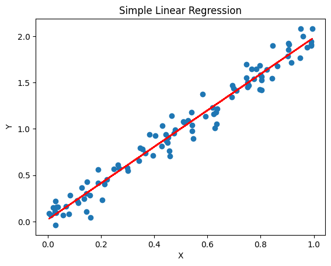

```python
# BEGIN SOLUTION
import numpy as np
import matplotlib.pyplot as plt

x = np.random.rand(100)
Y = 2 * x + np.random.normal(0, 0.1, 100)

corr_coef = np.corrcoef(x, Y)[0, 1]

X = sm.add_constant(x)
model = sm.OLS(Y, X).fit()
print(model.summary())
R_squared = model.rsquared
Y_pred = model.predict(X)

print("Correlation coefficient:", corr_coef)
print("Square of Correlation coefficient:", corr_coef*corr_coef)
print("R-squared:", R_squared)

# Plot the data and the regression line
plt.scatter(x, Y)
plt.plot(x, Y_pred, color='red')
plt.xlabel('X')
plt.ylabel('Y')
plt.title('Simple Linear Regression')
plt.show()

# END SOLUTION
```

In the above data,

Therefore, Square of Correlation coefficient is equal to R-squared. (difference in last decimal point can be ignored)